# Bootstrap Chi-Square and Correlation

Xuhao Dong

## Introduction

In this assignment we explore the (semi-) familiar statistics we learned to measure the association between variables. When we have two categorical variables, we use the $\chi^2$ test of association, which is based on the $\chi^2$ statistic. With two continuous variables, and some assumptions such as a linear relationship between them, we use the correlation coefficient, which comes with its own statistical test.

We’ll calculate these statistics in a manual fashion (something you’d *never* do in real life). We’ll then use bootstrapping to estimate standard errors of the statistics. We’ll draw inference from those standard errors and compare the outcome to the tests we’re more familiar with.

You might fairly ask why you need to calculate these statistics manually, when there are fast and reliable functions that will give you the same value in a fraction of the time. We’re mainly doing two things here: refreshing previous knowledge and learning the bootstrapping process. It’s easy to take a stats class that results in you vaguely knowing the $\chi^2$ statistic and correlation coefficient (symbolized by $\rho$). But writing the code from scratch usually locks in the ideas more firmly.

With regard to the bootstrap process, it’s not too important here, as you’ll see below. In most cases the traditional approaches to estimating these quantities (seen in `chisq.test` and `cor.test`) are fine. Here the bootstrap is like squirrel hunting with a bazooka. The power of the bootstrap is the ability to make good estimates of standard errors in situations where you have statistics that are *not* well behaved (or not well behaved with your population). See these statistics as a safe place to learn how to code up something like this. I’m also hopeful that you might be able to use a function like this in a case where the R function won’t work with your data for some reason.

There’s a secret third benefit as well. By writing code that matches the statistical software, you’re likely to trust your own abilities more. And the bootstrap method!

```r
d <- read_tsv(paste(here(),"survey_data.txt",sep="/"))

d.small <- d %>%
  filter(region %in% c("Thurston","W WA Non Metro"),
         engagement != "Not Engaged") %>%
  mutate(engagement = factor(engagement,
                             levels=c("Engaged","Highly Engaged")))
```

## $\chi^2$ Bootstrapping

The $\chi^2$ statistic is based on the counts in contingency tables. For instance in the Washington State financial institution survey data, we have the following table of counts for region by engagement in the bank.

|  | Engaged | Highly Engaged |
| --- | --- | --- |
| Thurston | 245 | 309 |
| W WA Non Metro | 88 | 88 |

There appears to be some association, and we can use the $\chi^2$ statistic to measure it. The null hypothesis assumes independence, calculates the expected values in each cell, and then compares those to what we actually see. If we number the cells $1, \ldots, k$, then the $\chi^2$ test starts by calculating
$$\sum_{i=1}^{k} \frac{(O_i - E_i)^2}{E_i}$$
where $O_i$ is the observed value in cell $i$ and $E_i$ is the expected value in that cell. This sum is normalized by the number of rows and columns. (To be precise, it is divided by $(r-1)\cdot(c-1)$ where $r$ is the number of rows and $c$ is the number of columns. This minus-one construct is done for the exact same reasons we have $l-1$ dummy variables for a categorical variable that has $l$ levels.) This normalized sum has a theoretical distribution. In R we can just call the `chisq.test` function:

```r
chi.test <- chisq.test(table(d.small$region, d.small$engagement), correct = F)

chi.test
```

```
##
##  Pearson's Chi-squared test
##
## data:  table(d.small$region, d.small$engagement)
## X-squared = 1.7964, df = 1, p-value = 0.1802
```

This returned a $\chi^2$ statistic of 1.7964 and a p-value of 0.1802. This p-value is not significant.

You should find the $\chi^2$ statistic is 1.7964 here[^1]. This is the result of calculating the expected value in every cell and comparing it to the observed values. Let’s do that now.

To understand the expected cell value, we make an assumption of independence and assume the region and engagement proportions apply evenly across the other dimension. If we look at the whole table, we see that 554 members are in Thurston county, a fraction of 0.759. Similarly, 0.544 are “Highly Engaged”. If there were no association between the columns, we would expect that you could multiply these fractions by the number of rows (730) and get 301.285 people in this cell. Instead we have 309.

Let’s automate the calculation of those expected values. Write a function that takes two vectors (let’s call them $a$ and $b$) as input and returns a table in the same form as `table(a,b)`, but with expected values in the cells. I have a stub here to help you get started. One tip, the `outer` function could save you some time here.

```r
exp.chi.sq <- function(a,b){
  raw.table <- table(a,b)

  p.row <- rowSums(raw.table)/sum(raw.table)
  p.col <- colSums(raw.table)/sum(raw.table)

  p.tbl <- outer(p.row, p.col)

  return(p.tbl * sum(raw.table))
}
```

```r
assert_that(abs(exp.chi.sq(d.small$region,d.small$engagement)[1,2]-301.3) <= 0.5,
            msg="Your expected chi-sq function isn't returning the correct value!")
```

```
## [1] TRUE
```

```r
# Assertions are a great way to test your code in place.
```

Once you have the expected values, you can take advantage of the fact that R works on matrices item by item. If you store the expected values in a matrix called `E` and the observed in one called `O`, then `sum((E-O)^2/E)` will give you the statistic. Write that function below. As before, have your function accept two vectors, `a` and `b`.

```r
chi.sq.stat <- function(a,b){

  E <- exp.chi.sq(a,b)
  O <- table(a,b)

  result <- sum((E-O)^2/E)

  return(result)
}

#chi.sq.stat(d.small$region,d.small$engagement)
```

```r
# Assertions are a great way to test your code in place.
assert_that(abs(chi.sq.stat(d.small$region,d.small$engagement)-1.8) <= 0.1,
            msg="Your chi-sq stat function isn't returning the correct value!")
```

```
## [1] TRUE
```

Now that we have the function written, let’s create a bootstrap estimate of the 90% confidence interval for our statistic (1.79) from our `d.small` data set. Plot the empirical density (using `geom_density`) and add the actual value as a vertical line on the plot.

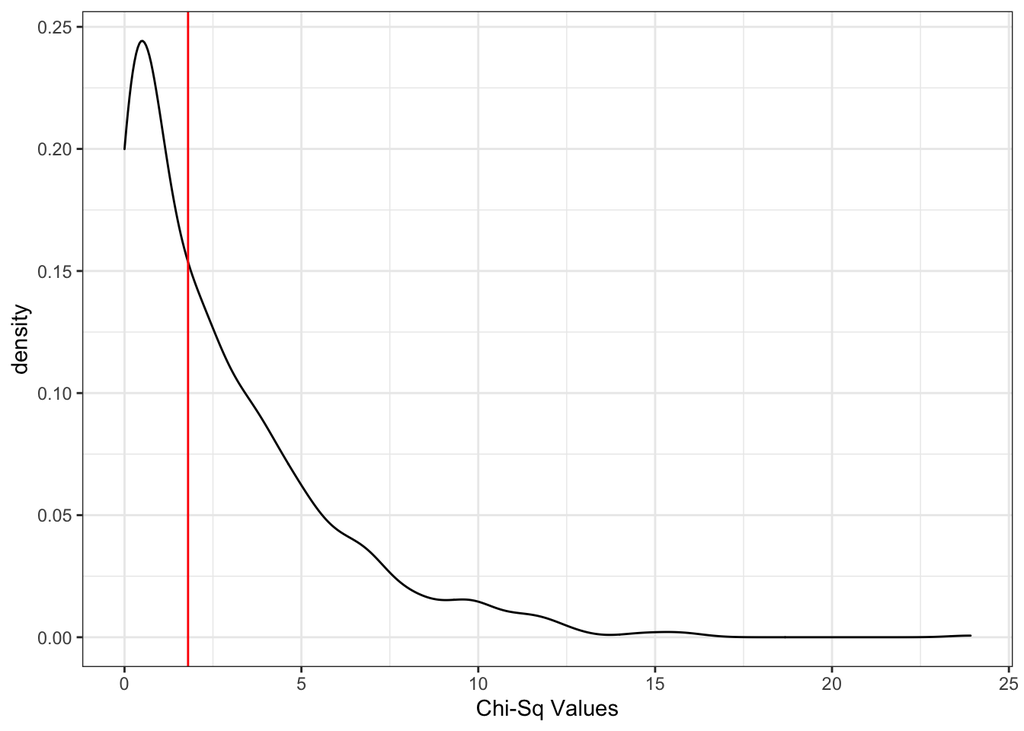

```r
n.sim <- 1000
results <- tibble(statistic=rep(NA,n.sim))

actual.value <- chi.sq.stat(d.small$region,d.small$engagement)

for(i in 1:n.sim){

  new.d <- d.small %>%
    slice_sample(n=nrow(d.small),replace=T)

  results$statistic[i] <- chi.sq.stat(new.d$region,new.d$engagement)
}

ggplot(results,
       aes(x=statistic)) +
  geom_density() +
  theme_bw() +
  labs(x="Chi-Sq Values") +
  geom_vline(xintercept=chi.sq.stat(d.small$region,d.small$engagement),col="red")
```

What do we see here? First, since our statistic is non-negative, we have a characteristically right-skewed distribution. We have  
0.509 of our replicates falling to the right of our statistic of 1.796. Note that we can calculate the standard error using this equation:

```r
sd(results$statistic)
```

```
## [1] 2.928355
```

Typically you’d calculate a confidence interval by taking, say, two standard errors on either side of the measured value. In this case that’d be an interval that started at -4.06 on the left and went up to 7.653 on the right. That’s absurd, since the lower bound can’t be any lower than zero. The problem is, as you can see from the chart, the normal distribution is a terrible approximation of this curve.

```r
quantile(results$statistic,probs=c(0.05,0.95))
```

```
##         5%        95%
## 0.02811804 8.81768456
```

This confidence interval is quite wide, indicating a great deal of uncertainty relative to the actual value. Statistics much smaller *and* much larger are plausible.

There’s no good way that I know of to turn this kind of bootstrap distribution into a hypothesis test. Could this value equal zero? Sure, there’s lots of probability at very small $\chi^2$ values. But the standard technique of turning a bootstrap resample into a hypothesis test won’t work here. As you may recall from class, that technique looks like this:

1. Use bootstrap resampling to get the distribution of your test statistic.
2. *Shift* that distribution to be in accordance with your null hypothesis, such as zero correlation. A $\chi^2$ statistic of *exactly* zero is implausible, but you could hypothesize a small value such as 1.
3. Compare your actual value to the shifted distribution. If it’s extreme, then you’re rejecting that null hypothesis.

The problem here is that shifting the distribution over doesn’t make any sense, the actual $\chi^2$ value is already small.

Now some work for you. We’ve been using `d.small`, which only included data on two regions and two engagement levels. Repeat what we’ve done, but for the entire data set (regions and three levels of engagement).

```r
chi.sq.stat(d$region, d$engagement)
```

```
## [1] 46.69496
```

```r
chisq.test(d$region, d$engagement)
```

```
##
##  Pearson's Chi-squared test
##
## data:  d$region and d$engagement
## X-squared = 46.695, df = 8, p-value = 1.753e-07
```

```r
#updated code from John and then I modified
n.sim <- 1000
results <- tibble(statistic=rep(NA,n.sim))

actual.value <- chi.sq.stat(d$region,d$engagement)

for(i in 1:n.sim){

  new.d <- d %>%
    slice_sample(n=nrow(d),replace=T)

  results$statistic[i] <- chi.sq.stat(new.d$region,new.d$engagement)
}

quantile(results$statistic,probs=c(0.05,.95))
```

```
##       5%      95%
## 32.70341 79.63063
```

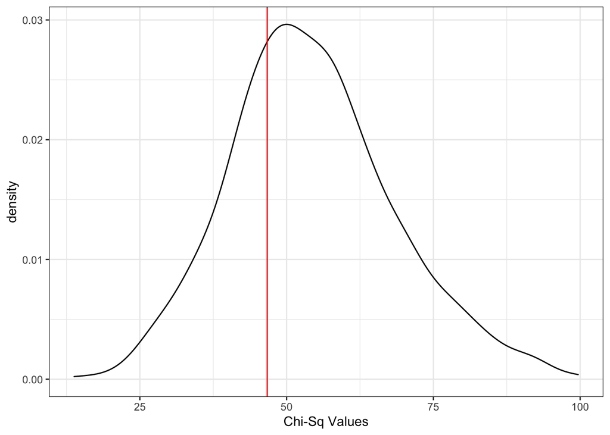

```r
ggplot(results,
       aes(x=statistic)) +
  geom_density() +
  theme_bw() +
  labs(x="Chi-Sq Values") +
  geom_vline(xintercept=chi.sq.stat(d$region,d$engagement),col="red")
```

## Correlation Coefficients

Let’s follow the example above but with the correlation coefficient. Recall that the definition of the correlation between $X$ and $Y$ (two random variables) is
$$\rho_{X,Y} = \frac{\textrm{cov}(X,Y)}{\sigma_X \cdot \sigma_Y}$$

We won’t calculate these statistics by hand, since `cov` and `sd` work just fine for our purposes, but we will build our own correlation coefficient. Here are the steps for this section of the assignment:

1. Write a function called `my.cor` that takes as input two vectors and returns the correlation coefficient between them. Verify that you get the same results as the `cor` function.
2. Use this function to calculate the correlation between age and progressivism.
3. Use bootstrap resampling to estimate the standard error of this correlation coefficient.
4. Does the measured correlation appear significant?
5. Compare your results to the output from `cor.test`.

## Results

```r
#write function  that takes as input two vectors, returns the correlation coefficient between them
  my.cor <- function(a,b){
    numerator <- cov(a,b)
    denominator <- sd(a)*sd(b)
    result <- numerator/denominator
    return(result)
  }

#a <- d$age
#b <- d$progressivism
#rm(a,b)

#Use this function to calculate the correlation between age and progressivism
my.cor(d$age, d$progressivism)
```

```
## [1] -0.04181309
```

```r
#Verify that you get the same results as the `cor`
cor(d$age, d$progressivism)
```

```
## [1] -0.04181309
```

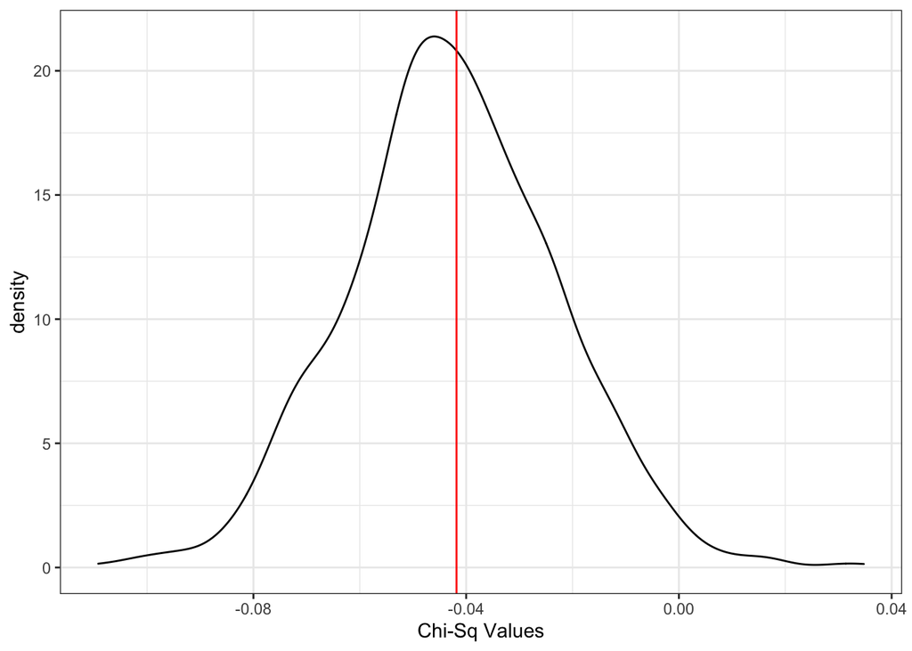

```r
# Use bootstrap resampling to estimate the standard error of this correlation coefficient.

n.sim <- 1000
results <- tibble(statistic=rep(NA,n.sim))

actual.value <- cor(d$age, d$progressivism)

for(i in 1:n.sim){

  new.d <- d %>%
    slice_sample(n=nrow(d),replace=T)

  results$statistic[i] <- cor(new.d$age,new.d$progressivism)
}

ggplot(results,
       aes(x=statistic)) +
  geom_density() +
  theme_bw() +
  labs(x="Chi-Sq Values") +
  geom_vline(xintercept=cor(d$age,d$progressivism),col="red")
```

```r
#Compare your results to the output from `cor.test`.
cor.test(d$age, d$progressivism)
```

```
##
##  Pearson's product-moment correlation
##
## data:  d$age and d$progressivism
## t = -2.0583, df = 2419, p-value = 0.03967
## alternative hypothesis: true correlation is not equal to 0
## 95 percent confidence interval:
##  -0.081514626 -0.001979077
## sample estimates:
##         cor
## -0.04181309
```

```r
quantile(results$statistic,probs=c(0.05,0.95))
```

```
##          5%         95%
## -0.07465397 -0.01050455
```

## Appendix: Full Data Description

A financial institution in Washington has become concerned that their current membership base is not well-aligned with their corporate values. Through that concern they realized that don’t actually understand their membership’s values very well. They surveyed 2,421 members to shed light on the issue.

The heart of the survey was the Moral Foundations Theory of Jonathan Haidt. Members were surveyed on the Moral Foundations Questionnaire, which you should take so you understand the test. Survey respondents were scored on the five foundations as well as a single-number summary, Progressivism.

The financial institution values Localism, Sustainability, and Education. These aspects of member’s values were assessed in the survey as well. Localism and Sustainability used validated scales and thus can be summarized via a single score, where higher values indicate greater support for the values. Education is summarized by the following three questions, which we do not have evidence can be combined into a single score:

- In general, public schools provide a better education than private schools.
- Public school teachers are underpaid.
- Experience is more important than education in determining success in life. These questions were evaluated on a 1 to 6 scale where 1 indicated “Strongly Disagree” and 6 indicated “Strongly Agree”.

Finally, we have information on the member that can be used to understand variation in their values.

The data consists of the following columns: